# Decentralization

Rose-Camille Vincent, Daniel Jemberu and Giulia Minnucci

Friday, November 07, 2014

Indicator for Decentralization: Decentralization typically defined in public planning, management and decision making as the transfer of authority and power from higher to lower levels of governing or from national to sub-national levels(Chema and Rondinelliei).it has different characterstics for different writers as describe as delegation,devaluation,de-concentration,and privatization of responsibility and authority of tasks to lower level of administration. Decentralization system involves two different measures: level and degree .decentralizations may occur at system or organization level(Mintzberg(1979).Degree can be defined as the distribution of power over the decision made inside an organization. Indicators for decentralization As defined above, decentralization is a complex multiple phenomenon, encompassing a number of political, fiscal and administrative dimension, it is difficult to capture the process and quantify for empirical study. So it leads to a challenge for measuring the outcome of decentralization on health provision system. Despite a number of theoretical frameworks, few try to measure the level and the extent of decentralization based on standard space map. The approach will consider both the fiscal and non fiscal aspects of decentralization. Such as Share of local income/ spending as a proportion of national income/spending ,major decentralization healthy program (dummy variable pre and post period),citizen participation (high, medium or low),governance rules on healthy offices(high,medium,or low) We proposed here to use a Revenue authonomy(RA) measure approch that, used in the (AkAI 2003) and (HABIBI and AL 2003)iteratures .This approach will consider both own municipalities revenue and total expenditure.Thus,takes the ratio of sub nationally financed administered revenue to the total expenditure that financed and administered by both central and sub national . Rhe following part will present and analyse Benin’s Revenue authonomy(RA) measure for 77 muncipalities from 2005-2010.

*Loading Data and cleaning

[output not shown]

[output cut: 756 more lines]

[output not shown]

[output cut: 448 more lines]

*Checking

```r
head(decentralazation)
```

```
##      Cities ID Year Decentralazation
## 1 Banikoara  1 2005            0.417
## 2 Banikoara  1 2006            0.611
## 3 Banikoara  1 2007            0.434
## 4 Banikoara  1 2008            0.440
## 5 Banikoara  1 2009            0.312
## 6 Banikoara  1 2010            0.447
```

```r
names(decentralazation)
```

```
## [1] "Cities"           "ID"               "Year"
## [4] "Decentralazation"
```

```r
tail(decentralazation)
```

```
##         Cities ID Year Decentralazation
## 457 Zogbodomey 77 2005            0.384
## 458 Zogbodomey 77 2006            0.455
## 459 Zogbodomey 77 2007            0.369
## 460 Zogbodomey 77 2008            0.459
## 461 Zogbodomey 77 2009            0.183
## 462 Zogbodomey 77 2010            0.240
```

```r
sum(is.na(decentralazation))
```

```
## [1] 0
```

```r
summary(decentralazation)
```

```
##            Cities          ID          Year      Decentralazation
##  Abomey       :  6   Min.   : 1   Min.   :2005   Min.   :0.046
##  Abomey-Calavi:  6   1st Qu.:20   1st Qu.:2006   1st Qu.:0.179
##  Adja-Ouere   :  6   Median :39   Median :2008   Median :0.300
##  Adjarra      :  6   Mean   :39   Mean   :2008   Mean   :0.352
##  Adjohoun     :  6   3rd Qu.:58   3rd Qu.:2009   3rd Qu.:0.475
##  Agbangnizoun :  6   Max.   :77   Max.   :2010   Max.   :1.061
##  (Other)      :426
```

```r
mean(decentralazation$Decentralazation)
```

```
## [1] 0.3524
```

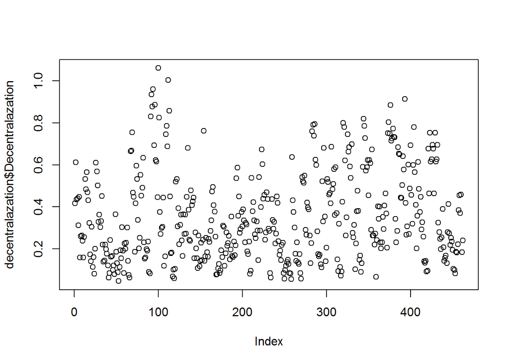

```r
plot(decentralazation$Decentralazation)
```

Reference

AkAI, M., N.& SAKATA. 2003. “Fiscal Decentralization Contributes to Economic Growth:Evidence from State-Level Cross-Section Data for the United States.” Decentralization; human development in argentina, 73.

Chema, G, and Rondinelliei. “Decentralization and Development.” Newburry park,CA, 14–31.

HABIBI, N, and ET AL. 2003. *The Role of the State in Industrial Policy, a Framework for Rethinking the Approach*. jouranal of human development.